# Intro to R

Jon Gewirtzman

2024-02-10

# Intro to Programming in R

This is an R tutorial largely sourced from [Intro2R.com](https://intro2r.com/), which also contains further detail about more complex programming capabilities. Feel free to check out the site to explore other things you can do in R! Once you have a sense of the basic syntax, R gives you a widely expansive, customizable, and powerful set of tools for any sort of data manipulation, analysis, and visualization. It can be intimidating to start with, but you don’t need to learn every part of it to use it– real programmers are always Googling “how do I do this particular task in R?”, and once you know the very basics, you can understand all of the resources out there to help you build your own code and programs.

A few points from Intro2R:

- Use R often and use it regularly - find any excuse to fire up RStudio (or just R) and get coding. This will help build and maintain all important momentum.
- Learning R is not a memory test. One of the beauties of a scripting language is that you will always have your code to refer back to when you inevitably forget how to do something.
- You don’t need to know everything there is to know about R to use it productively. If you get stuck, Google it, it’s not cheating and writing a good search query is a skill in itself. Just make sure you check thoroughly that the code you find is doing what you want it to do.
- If you find yourself staring at code for hours trying to figure out why it’s not working then walk away for a few minutes. We’ve lost count of the number of times we were able to spot our mistake almost immediately after returning from a short caffeine break.
- In R there are many ways to tackle a particular problem. If your code doesn’t look like someone elses, but it does what you want it to do in a reasonable time and robustly then don’t worry about it - job done.
- Related to our previous point, remember R is just a tool to help you answer your interesting questions. Although it can be fun to immerse yourself in all things R (we often do), don’t lose sight of what’s important - your research question(s) and your data. No amount of skill using R will help if your data collection is fundamentally flawed or your question vague.
- Recognise that there will be times when things will get a little tough or frustrating. Try to accept these periods as part of the natural process of learning a new skill (we’ve all been there) and remember, the time and energy you invest now will be more than payed back in the not too distant future.

## Basics

At a basic level we can use R much as you would use a calculator. We can type an arithmetic expression into our script, then source it into the console and receive a result. For example, if we type the expression 2 + 2 and then source this line of code we get the answer 4.

```r
2+2
```

```
## [1] 4
```

The [1] in front of the result tells you that the observation number at the beginning of the line is the first observation. This is not much help in this example, but can be quite useful when printing results with multiple lines (we’ll see an example below). The other obvious arithmetic operators are -, `*`, / for subtraction, multiplication and division respectively. R follows the usual mathematical convention of order of operations. For example, the expression 2 + 3 * 4 is interpreted to have the value 2 + (3 * 4) = 14, not (2 + 3) * 4 = 20. There are a huge range of mathematical functions in R, some of the most useful include; log(), log10(), exp(), sqrt().

```r
log(1)
```

```
## [1] 0
```

```r
exp(1)
```

```
## [1] 2.718282
```

```r
sqrt(4)
```

```
## [1] 2
```

```r
2^2
```

```
## [1] 4
```

```r
pi
```

```
## [1] 3.141593
```

Try experimenting with this so you get familiar with the operations. In the box below, write some arithmetic operations, and see that you get results that make sense. Note that in the box below, some text is following the “#” symbol, and is greyed-out. This is “comment” text. When text is written as a comment, it tells R not to run it as code; this allows us to write annotations, intructions, or descriptions in-line with the code, to make it more understandable. Adding a “#” to a line of text is called “commenting out” a line.

```r
#add your own arithmetic operations here, below this line
```

## Objects in R

At the heart of almost everything you will do (or ever likely to do) in R is the concept that everything in R is an object. These objects can be almost anything, from a single number or character string (like a word) to highly complex structures like the output of a plot, a summary of your statistical analysis or a set of R commands that perform a specific task. Understanding how you create objects and assign values to objects is key to understanding R.

To create an object we simply give the object a name. We can then assign a value to this object using the assignment operator <- (sometimes called the gets operator). The assignment operator is a composite symbol comprised of a ‘less than’ symbol < and a hyphen - .

```r
my_obj<-48

my_obj
```

```
## [1] 48
```

Now that we’ve created this object, R knows all about it and will keep track of it during this current R session. All of the objects you create will be stored in the current workspace and you can view all the objects in your workspace in RStudio by clicking on the ‘Environment’ tab in the top right hand pane.

If you click on the down arrow on the ‘List’ icon in the same pane and change to ‘Grid’ view RStudio will show you a summary of the objects including the type (numeric - it’s a number), the length (only one value in this object), its ‘physical’ size and its value (48 in this case).

There are many different types of values that you can assign to an object. For example

```r
my_obj2 <- "R is cool"

my_obj2
```

```
## [1] "R is cool"
```

Here we have created an object called my_obj2 and assigned it a value of R is cool which is a character string. Notice that we have enclosed the string in quotes. If you forget to use the quotes you will receive an error message. Try removing the quotes here and see what happens.

```r
my_obj3 <- "R is cool"

my_obj3
```

```
## [1] "R is cool"
```

To change the value of an existing object we simply reassign a new value to it. For example, to change the value of my_obj2 from “R is cool” to the number 1024

```r
my_obj2 <- 1024

my_obj2
```

```
## [1] 1024
```

Try creating your own objects here. Try creating a numeric object and a character object, and then “call” those objects (i.e., write their names, and run the code) to see that R returns the correct values of these objects.

```r
#create a numeric object brlow


#call the object below


#create a character object below


#call the object below
```

Once we have created a few objects, we can do stuff with our objects. For example, the following code creates a new object my_obj3 and assigns it the value of my_obj added to my_obj2 which is 1072 (48 + 1024 = 1072).

```r
my_obj3 <- my_obj + my_obj2

my_obj3
```

```
## [1] 1072
```

Notice that to display the value of my_obj3 we also need to write the object’s name. The above code works because the values of both my_obj and my_obj2 are numeric (i.e. a number). If you try to do this with objects with character values (character class) you will receive an error. Try creating an object called “char_obj3” by adding “char_obj” and “char_obj2” together, and see what happens.

```r
char_obj <- "hello"
char_obj2 <- "world!"

#your code below
```

Naming your objects is one of the most difficult things you will do in R (honestly - we’re serious). Ideally your object names should be kept both short and informative which is not always easy. If you need to create objects with multiple words in their name then use either an underscore or a dot between words or capitalise the different words. We prefer the underscore format (called snake case)

output_summary <- “my analysis” output.summary <- “my analysis” outputSummary <- “my analysis” There are also a few limitations when it come to giving objects names. An object name cannot start with a number or a dot followed by a number (i.e. 2my_variable or .2my_variable). You should also avoid using non-alphanumeric characters in your object names (i.e. &, ^, /, ! etc). In addition, make sure you don’t name your objects with reserved words (i.e. TRUE, NA) and it’s never a good idea to give your object the same name as a built-in function.

## Functions in R

Up until now we’ve been creating simple objects by directly assigning a single value to an object. It’s very likely that you’ll soon want to progress to creating more complicated objects as your R experience grows and the complexity of your tasks increase. Happily, R has a multitude of functions to help you do this. You can think of a function as an object which contains a series of instructions to perform a specific task. The base installation of R comes with many functions already defined or you can increase the power of R by installing one of the 10000’s of packages now available. Once you get a bit more experience with using R you may want to define your own functions to perform tasks that are specific to your goals.

## Built-In Functions

The first function we will learn about is the c() function. The c() function is short for concatenate and we use it to join together a series of values and store them in a data structure called a vector.

```r
my_vec <- c(2, 3, 1, 6, 4, 3, 3, 7)
```

In the code above we’ve created an object called my_vec and assigned it a value using the function c(). There are a couple of really important points to note here. Firstly, when you use a function in R, the function name is always followed by a pair of round brackets even if there’s nothing contained between the brackets. Secondly, the argument(s) of a function are placed inside the round brackets and are separated by commas. You can think of an argument as way of customising the use or behaviour of a function. In the example above, the arguments are the numbers we want to concatenate. Finally, one of the tricky things when you first start using R is to know which function to use for a particular task and how to use it. Thankfully each function will always have a help document associated with it which will explain how to use the function (more on this later) and a quick Google search will also usually help you out.

To examine the value of our new object we can simply type out the name of the object as we did before.

```r
my_vec
```

```
## [1] 2 3 1 6 4 3 3 7
```

Now that we’ve created a vector we can use other functions to do useful stuff with this object. For example, we can calculate the mean, variance, standard deviation and number of elements in our vector by using the mean(), var(), sd() and length() functions

```r
mean(my_vec)    # returns the mean of my_vec
```

```
## [1] 3.625
```

```r
var(my_vec)     # returns the variance of my_vec
```

```
## [1] 3.982143
```

```r
sd(my_vec)      # returns the standard deviation of my_vec
```

```
## [1] 1.995531
```

```r
length(my_vec)  # returns the number of elements in my_vec
```

```
## [1] 8
```

If we wanted to use any of these values later on in our analysis we can just assign the resulting value to another object

```r
vec_mean <- mean(my_vec)    # returns the mean of my_vec
vec_mean
```

```
## [1] 3.625
```

Sometimes it can be useful to create a vector that contains a regular sequence of values in steps of one. Here we can make use of a shortcut using the : symbol. Other useful functions for generating vectors of sequences include the seq() and rep() functions. For example, to generate a sequence from 1 to 5 in steps of 0.5

```r
my_seq <- 1:10     # create regular sequence
my_seq
```

```
##  [1]  1  2  3  4  5  6  7  8  9 10
```

```r
my_seq2 <- 10:1    # in decending order
my_seq2
```

```
##  [1] 10  9  8  7  6  5  4  3  2  1
```

```r
my_seq2 <- seq(from = 1, to = 5, by = 0.5)
my_seq2
```

```
## [1] 1.0 1.5 2.0 2.5 3.0 3.5 4.0 4.5 5.0
```

```r
my_seq3 <- rep(2, times = 10)   # repeats 2, 10 times
my_seq3
```

```
##  [1] 2 2 2 2 2 2 2 2 2 2
```

```r
my_seq4 <- rep("abc", times = 3)    # repeats ‘abc’ 3 times
my_seq4
```

```
## [1] "abc" "abc" "abc"
```

```r
my_seq5 <- rep(1:5, times = 3)  # repeats the series 1 to 5, 3 times
my_seq5
```

```
##  [1] 1 2 3 4 5 1 2 3 4 5 1 2 3 4 5
```

```r
my_seq6 <- rep(1:5, each = 3)   # repeats each element of the series 3 times
my_seq6
```

```
##  [1] 1 1 1 2 2 2 3 3 3 4 4 4 5 5 5
```

We can also repeat a non-sequential series

```r
my_seq7 <- rep(c(3, 1, 10, 7), each = 3) # repeats each
                                         # element of the
                                         # series 3 times
my_seq7
```

```
##  [1]  3  3  3  1  1  1 10 10 10  7  7  7
```

Note in the code above how we’ve used the c() function inside the rep() function. Nesting functions allows us to build quite complex commands within a single line of code and is a very common practice when using R. However, care needs to be taken as too many nested functions can make your code quite difficult for others to understand (or yourself some time in the future!). We could rewrite the code above to explicitly separate the two different steps to generate our vector. Either approach will give the same result, you just need to use your own judgement as to which is more readable.

```r
in_vec <- c(3, 1, 10, 7)
my_seq7 <- rep(in_vec, each = 3)    # repeats each element of
                                  # the series 3 times
my_seq7
```

```
##  [1]  3  3  3  1  1  1 10 10 10  7  7  7
```

## Custom Functions

R has lots of built-in functions, and more can be added through packages (we’ll explain packages below). To use built-in functions (or those loaded through packages), we’ve seen that we “call” them with the notation function(), and arguments to the function. But we can also build our own.

A function takes an object and does something to it. This is just like in math class, where a function f(x) takes x and does some operation to it. In the function f(x)=x+1, f() takes a number x, and adds 1 to it, so that f(3)=4. This is just the same in R. Let’s build a function that takes an input, multiplies it by 3, and subtracts 2. We use the notation function(x), where x is an argument to the function. The function is then defined in curly brackets. So, it would look like:

```r
my_function<-function(x){x*3-2}
```

Now, we can use this function, with different arguments (a.k.a. inputs to the function)

```r
my_function(x=1)
```

```
## [1] 1
```

```r
my_function(x=-2)
```

```
## [1] -8
```

```r
my_function(x=pi)
```

```
## [1] 7.424778
```

We can make functions take multiple arguments. Let’s make a function to take a number, multiply it by 2, take another number multiplied by 3, and add them together.

```r
my_function_2<-function(x, y){x*2 + y*3}

my_function_2(x=1, y=1)
```

```
## [1] 5
```

```r
my_function_2(x=1, y=2)
```

```
## [1] 8
```

```r
my_function_2(x=25, y=100)
```

```
## [1] 350
```

What we name variables is arbitrary; we just use these to help understand the function. What the variables do is defined by the function. So, we could also write the above function like:

```r
my_function_3<-function(input1, input2){input1*2 + input2*3}

my_function_3(input1=25, input2=100)
```

```
## [1] 350
```

In fact, we don’t even need to specify the variable names in the function call. However, it is *very* helpful to do so, especially when you’re new to using a function, in order to keep track of which arguments are which, and make sure they’re doing the things you want them to do. But, it can work without them:

```r
my_function_2(25, 100)
```

```
## [1] 350
```

Try writing your own function that squares a number and adds 10.

```r
#your function below
```

All of the functions built into R or loaded through packages are written in this format, using basic data operations and stitching them together. For example, you can view the “source code” of the sd() function, which returns standard deviation of an input vector. We can use print() to have the console display some item, and see what sd() is doing under the hood. Don’t mind all of the detail for now, but you can see that sd() is taking a variable x, and finding the square root of its variance. This is the kind of thing that happens any time you use any function.

```r
print(sd)
```

```
## function (x, na.rm = FALSE)
## sqrt(var(if (is.vector(x) || is.factor(x)) x else as.double(x),
##     na.rm = na.rm))
## <bytecode: 0x7f8d6093aa50>
## <environment: namespace:stats>
```

## Vectors

We made and used some vectors above. Vectors are an important data structure in R, and we will now explore them in more detail.

### Extracting Elements

To extract (also known as indexing or subscripting) one or more values (more generally known as elements) from a vector we use the square bracket [ ] notation. The general approach is to name the object you wish to extract from, then a set of square brackets with an index of the element you wish to extract contained within the square brackets. This index can be a position or the result of a logical test.

To extract elements based on their position we simply write the position inside the [ ]. For example, to extract the 3rd value of my_vec

```r
my_vec        # remind ourselves what my_vec looks like
```

```
## [1] 2 3 1 6 4 3 3 7
```

```r
my_vec[3]     # extract the 3rd value
```

```
## [1] 1
```

```r
# if you want to store this value in another object
val_3 <- my_vec[3]
val_3
```

```
## [1] 1
```

Note that the positional index starts at 1 rather than 0 like some other other programming languages (i.e. Python).

We can also extract more than one value by using the c() function inside the square brackets. Here we extract the 1st, 5th, 6th and 8th element from the my_vec object. Or we can extract a range of values using the : notation. To extract the values from the 3rd to the 8th elements.

```r
my_vec[c(1, 5, 6, 8)]
```

```
## [1] 2 4 3 7
```

```r
my_vec[3:8]
```

```
## [1] 1 6 4 3 3 7
```

Another really useful way to extract data from a vector is to use a logical expression as an index. For example, to extract all elements with a value greater than 4 in the vector my_vec

```r
my_vec[my_vec > 4]
```

```
## [1] 6 7
```

Here, the logical expression is my_vec > 4 and R will only extract those elements that satisfy this logical condition. So how does this actually work? If we look at the output of just the logical expression without the square brackets you can see that R returns a vector containing either TRUE or FALSE which correspond to whether the logical condition is satisfied for each element. In this case only the 4th and 8th elements return a TRUE as their value is greater than 4.

```r
my_vec > 4
```

```
## [1] FALSE FALSE FALSE  TRUE FALSE FALSE FALSE  TRUE
```

So what R is actually doing under the hood is equivalent to

```r
my_vec[c(FALSE, FALSE, FALSE, TRUE, FALSE, FALSE, FALSE, TRUE)]
```

```
## [1] 6 7
```

and only those element that are TRUE will be extracted.

In addition to the < and > operators you can also use composite operators to increase the complexity of your expressions. For example the expression for ‘greater or equal to’ is >=. To test whether a value is equal to a value we need to use a double equals symbol == and for ‘not equal to’ we use != (the ! symbol means ‘not’).

```r
my_vec[my_vec >= 4]        # values greater or equal to 4
```

```
## [1] 6 4 7
```

```r
my_vec[my_vec < 4]         # values less than 4
```

```
## [1] 2 3 1 3 3
```

```r
my_vec[my_vec <= 4]        # values less than or equal to 4
```

```
## [1] 2 3 1 4 3 3
```

```r
my_vec[my_vec == 4]        # values equal to 4
```

```
## [1] 4
```

```r
my_vec[my_vec != 4]        # values not equal to 4
```

```
## [1] 2 3 1 6 3 3 7
```

Try writing your own code here to extract the values of my_vec that are equal to 3:

```r
#your code here
```

We can also combine multiple logical expressions using Boolean expressions. In R the & symbol means AND and the | symbol means OR. For example, to extract values in my_vec which are less than 6 AND greater than 2

```r
val26 <- my_vec[my_vec < 6 & my_vec > 2]
val26
```

```
## [1] 3 4 3 3
```

or extract values in my_vec that are greater than 6 OR less than 3

```r
val63 <- my_vec[my_vec > 6 | my_vec < 3]
val63
```

```
## [1] 2 1 7
```

### Replacing and Ordering Elements

We can change the values of some elements in a vector using our [ ] notation in combination with the assignment operator <-. For example, to replace the 4th value of our my_vec object from 6 to 500

```r
my_vec
```

```
## [1] 2 3 1 6 4 3 3 7
```

```r
my_vec[4] <- 500

my_vec
```

```
## [1]   2   3   1 500   4   3   3   7
```

We can also replace more than one value or even replace values based on a logical expression

```r
# replace the 6th and 7th element with 100
my_vec[c(6, 7)] <- 100
my_vec
```

```
## [1]   2   3   1 500   4 100 100   7
```

```r
# replace element that are less than or equal to 4 with 1000
my_vec[my_vec <= 4] <- 1000
my_vec
```

```
## [1] 1000 1000 1000  500 1000  100  100    7
```

In addition to extracting particular elements from a vector we can also order the values contained in a vector. To sort the values from lowest to highest value we can use the sort() function

```r
vec_sort <- sort(my_vec)
vec_sort
```

```
## [1]    7  100  100  500 1000 1000 1000 1000
```

To reverse the sort, from highest to lowest, we can either include the decreasing = TRUE argument when using the sort() function, or first sort the vector using the sort() function and then reverse the sorted vector using the rev() function. This is another example of nesting one function inside another function.

```r
vec_sort2 <- sort(my_vec, decreasing = TRUE)
vec_sort2
```

```
## [1] 1000 1000 1000 1000  500  100  100    7
```

```r
vec_sort3 <- rev(sort(my_vec))
vec_sort3
```

```
## [1] 1000 1000 1000 1000  500  100  100    7
```

Whilst sorting a single vector is fun, perhaps a more useful task would be to sort one vector according to the values of another vector. To do this we should use the order() function in combination with [ ]. To demonstrate this let’s create a vector called height containing the height of 5 different people and another vector called p.names containing the names of these people (so Joanna is 180 cm, Charlotte is 155 cm etc)

```r
height <- c(180, 155, 160, 167, 181)
height
```

```
## [1] 180 155 160 167 181
```

```r
p.names <- c("Joanna", "Charlotte", "Helen", "Karen", "Amy")
p.names
```

```
## [1] "Joanna"    "Charlotte" "Helen"     "Karen"     "Amy"
```

Our goal is to order the people in p.names in ascending order of their height. The first thing we’ll do is use the order() function with the height variable to create a vector called height_ord

```r
height_ord <- order(height)
height_ord
```

```
## [1] 2 3 4 1 5
```

OK, what’s going on here? The first value, 2, (remember ignore [1]) should be read as ‘the smallest value of height is the second element of the height vector’. If we check this by looking at the height vector above, you can see that element 2 has a value of 155, which is the smallest value. The second smallest value in height is the 3rd element of height, which when we check is 160 and so on. The largest value of height is element 5 which is 181. Now that we have a vector of the positional indices of heights in ascending order (height_ord), we can extract these values from our p.names vector in this order

```r
names_ord <- p.names[height_ord]
names_ord
```

```
## [1] "Charlotte" "Helen"     "Karen"     "Joanna"    "Amy"
```

You’re probably thinking ‘what’s the use of this?’ Well, imagine you have a dataset which contains two columns of data and you want to sort each column. If you just use sort() to sort each column separately, the values of each column will become uncoupled from each other. By using the ‘order()’ on one column, a vector of positional indices is created of the values of the column in ascending order This vector can be used on the second column, as the index of elements which will return a vector of values based on the first column.

### Vectorization

One of the great things about R functions is that most of them are vectorised. This means that the function will operate on all elements of a vector without needing to apply the function on each element separately. For example, to multiple each element of a vector by 5 we can simply use

```r
# create a vector
my_vec2 <- c(3, 5, 7, 1, 9, 20)

# multiply each element by 5
my_vec2 * 5
```

```
## [1]  15  25  35   5  45 100
```

Or we can add the elements of two or more vectors

```r
# create a second vector
my_vec3 <- c(17, 15, 13, 19, 11, 0)

# add both vectors
my_vec2 + my_vec3
```

```
## [1] 20 20 20 20 20 20
```

```r
# multiply both vectors
my_vec2 * my_vec3
```

```
## [1] 51 75 91 19 99  0
```

However, you must be careful when using vectorisation with vectors of different lengths as R will quietly recycle the elements in the shorter vector rather than throw a wobbly (error).

```r
# create a third vector
my_vec4 <- c(1, 2)

# add both vectors - quiet recycling!
my_vec2 + my_vec4
```

```
## [1]  4  7  8  3 10 22
```

### Missing Data

In R, missing data is usually represented by an NA symbol meaning ‘Not Available’. Data may be missing for a whole bunch of reasons, maybe your machine broke down, maybe you broke down, maybe the weather was too bad to collect data on a particular day etc etc. Missing data can be a pain in the proverbial both from an R perspective and also a statistical perspective. From an R perspective missing data can be problematic as different functions deal with missing data in different ways. For example, let’s say we collected air temperature readings over 10 days, but our thermometer broke on day 2 and again on day 9 so we have no data for those days. We now want to calculate the mean temperature over these days using the mean() function.

```r
temp  <- c(7.2, NA, 7.1, 6.9, 6.5, 5.8, 5.8, 5.5, NA, 5.5)
temp
```

```
##  [1] 7.2  NA 7.1 6.9 6.5 5.8 5.8 5.5  NA 5.5
```

```r
mean_temp <- mean(temp)
mean_temp
```

```
## [1] NA
```

What’s happened here? Why does the mean() function return an NA? Actually, R is doing something very sensible (at least in our opinion!). If a vector has a missing value then the only possible value to return when calculating a mean is NA. R doesn’t know that you perhaps want to ignore the NA values (R can’t read your mind - yet!). Happily, if we look at the help file (use help(“mean”) associated with the mean() function we can see there is an argument na.rm = which is set to FALSE by default.

```r
help("mean")

?mean()

?mean
```

## Data Types

R is able to store several types of data:

- Numeric data are numbers that contain a decimal. Actually they can also be whole numbers but we’ll gloss over that.
- Integers are whole numbers (those numbers without a decimal point).
- Logical data take on the value of either TRUE or FALSE. There’s also another special type of logical called NA to represent missing values.
- Character data are used to represent string values. You can think of character strings as something like a word (or multiple words). A special type of character string is a factor, which is a string but with additional attributes (like levels or an order). We’ll cover factors later.
- Complex numbers (we will skip this for now).
- Raw data (we will skip this for now, too).

R is (usually) able to automatically distinguish between different classes of data by their nature and the context in which they’re used although you should bear in mind that R can’t actually read your mind and you may have to explicitly tell R how you want to treat a data type. You can find out the type (or class) of any object using the class() function.

```r
num <- 2.2
class(num)
```

```
## [1] "numeric"
```

```r
char <- "hello"
class(char)
```

```
## [1] "character"
```

```r
logi <- TRUE
class(logi)
```

```
## [1] "logical"
```

Alternatively, you can ask if an object is a specific class using using a logical test. The is.classOfData family of functions will return either a TRUE or a FALSE.

```r
is.numeric(num)
```

```
## [1] TRUE
```

```r
is.character(num)
```

```
## [1] FALSE
```

```r
is.character(char)
```

```
## [1] TRUE
```

```r
is.logical(logi)
```

```
## [1] TRUE
```

It can sometimes be useful to be able to change the class of a variable using the as.className family of coercion functions, although you need to be careful when doing this as you might receive some unexpected results (see what happens below when we try to convert a character string to a numeric).

```r
# coerce numeric to character
class(num)
```

```
## [1] "numeric"
```

```r
num_char <-  as.character(num)
num_char
```

```
## [1] "2.2"
```

```r
class(num_char)
```

```
## [1] "character"
```

```r
# coerce character to numeric!
class(char)
```

```
## [1] "character"
```

```r
#try this one and see what happens
char_num <- as.numeric(char)
```

Perhaps the simplest type of data structure is the vector. You’ve already been introduced to vectors, although some of the vectors you created only contained a single value. Vectors that have a single value (length 1) are called scalars. Vectors can contain numbers, characters, factors or logicals, but the key thing to remember is that all the elements inside a vector must be of the same class. In other words, vectors can contain either numbers, characters or logicals but not mixtures of these types of data. There is one important exception to this, you can include NA (remember this is special type of logical) to denote missing data in vectors with other data types.

Another useful data structure used in many disciplines such as population ecology, theoretical and applied statistics is the matrix. A matrix is simply a vector that has additional attributes called dimensions. Arrays are just multidimensional matrices. Again, matrices and arrays must contain elements all of the same data class.

### Matrices, Scalars, Arrays and Lists

A convenient way to create a matrix or an array is to use the matrix() and array() functions respectively. Below, we will create a matrix from a sequence 1 to 16 in four rows (nrow = 4) and fill the matrix row-wise (byrow = TRUE) rather than the default column-wise. When using the array() function we define the dimensions using the dim = argument, in our case 2 rows, 4 columns in 2 different matrices.

```r
my_mat <- matrix(1:16, nrow = 4, byrow = TRUE)
my_mat
```

```
##      [,1] [,2] [,3] [,4]
## [1,]    1    2    3    4
## [2,]    5    6    7    8
## [3,]    9   10   11   12
## [4,]   13   14   15   16
```

```r
my_array <- array(1:16, dim = c(2, 4, 2))
my_array
```

```
## , , 1
##
##      [,1] [,2] [,3] [,4]
## [1,]    1    3    5    7
## [2,]    2    4    6    8
##
## , , 2
##
##      [,1] [,2] [,3] [,4]
## [1,]    9   11   13   15
## [2,]   10   12   14   16
```

Sometimes it’s also useful to define row and column names for your matrix but this is not a requirement. To do this use the rownames() and colnames() functions.

```r
rownames(my_mat) <- c("A", "B", "C", "D")
colnames(my_mat) <- c("a", "b", "c", "d")
my_mat
```

```
##    a  b  c  d
## A  1  2  3  4
## B  5  6  7  8
## C  9 10 11 12
## D 13 14 15 16
```

Once you’ve created your matrices you can do useful stuff with them and as you’d expect, R has numerous built in functions to perform matrix operations. Some of the most common are given below. For example, to transpose a matrix we use the transposition function t() To extract the diagonal elements of a matrix and store them as a vector we can use the diag() function.

```r
my_mat_t <- t(my_mat)
my_mat_t
```

```
##   A B  C  D
## a 1 5  9 13
## b 2 6 10 14
## c 3 7 11 15
## d 4 8 12 16
```

```r
my_mat_diag <- diag(my_mat)
my_mat_diag
```

```
## [1]  1  6 11 16
```

The usual matrix addition, multiplication etc can be performed. Note the use of the %*% operator to perform matrix multiplication.

```r
mat.1 <- matrix(c(2, 0, 1, 1), nrow = 2)    # notice that the matrix has been filled
mat.1                                     # column-wise by default
```

```
##      [,1] [,2]
## [1,]    2    1
## [2,]    0    1
```

```r
mat.2 <- matrix(c(1, 1, 0, 2), nrow = 2)
mat.2
```

```
##      [,1] [,2]
## [1,]    1    0
## [2,]    1    2
```

```r
mat.1 + mat.2           # matrix addition
```

```
##      [,1] [,2]
## [1,]    3    1
## [2,]    1    3
```

```r
mat.1 * mat.2           # element by element products
```

```
##      [,1] [,2]
## [1,]    2    0
## [2,]    0    2
```

```r
mat.1 %*% mat.2         # matrix multiplication
```

```
##      [,1] [,2]
## [1,]    3    2
## [2,]    1    2
```

### Lists

The next data structure we will quickly take a look at is a list. Whilst vectors and matrices are constrained to contain data of the same type, lists are able to store mixtures of data types. In fact we can even store other data structures such as vectors and arrays within a list or even have a list of a list. This makes for a very flexible data structure which is ideal for storing irregular or non-rectangular data. To create a list we can use the list() function. Note how each of the three list elements are of different classes (character, logical, and numeric) and are of different lengths.

```r
list_1 <- list(c("black", "yellow", "orange"),
               c(TRUE, TRUE, FALSE, TRUE, FALSE, FALSE),
               matrix(1:6, nrow = 3))
list_1
```

```
## [[1]]
## [1] "black"  "yellow" "orange"
##
## [[2]]
## [1]  TRUE  TRUE FALSE  TRUE FALSE FALSE
##
## [[3]]
##      [,1] [,2]
## [1,]    1    4
## [2,]    2    5
## [3,]    3    6
```

Elements of the list can be named during the construction of the list, or after the list has been created using the names() function.

```r
list_2 <- list(colours = c("black", "yellow", "orange"),
               evaluation = c(TRUE, TRUE, FALSE, TRUE, FALSE, FALSE),
               time = matrix(1:6, nrow = 3))
list_2
```

```
## $colours
## [1] "black"  "yellow" "orange"
##
## $evaluation
## [1]  TRUE  TRUE FALSE  TRUE FALSE FALSE
##
## $time
##      [,1] [,2]
## [1,]    1    4
## [2,]    2    5
## [3,]    3    6
```

```r
names(list_1) <- c("colours", "evaluation", "time")
list_1
```

```
## $colours
## [1] "black"  "yellow" "orange"
##
## $evaluation
## [1]  TRUE  TRUE FALSE  TRUE FALSE FALSE
##
## $time
##      [,1] [,2]
## [1,]    1    4
## [2,]    2    5
## [3,]    3    6
```

## Data Frames

By far the most commonly used data structure to store data in is the data frame. A data frame is a powerful two-dimensional object made up of rows and columns which looks superficially very similar to a matrix. However, whilst matrices are restricted to containing data all of the same type, data frames can contain a mixture of different types of data. Typically, in a data frame each row corresponds to an individual observation and each column corresponds to a different measured or recorded variable. This setup may be familiar to those of you who use LibreOffice Calc or Microsoft Excel to manage and store your data. Perhaps a useful way to think about data frames is that they are essentially made up of a bunch of vectors (columns) with each vector containing its own data type but the data type can be different between vectors.

Here is an example dataframe in R, built-in to the language as an example.

The Iris dataset is a classic dataset in the field of machine learning and statistics, often used for demonstrating classification algorithms. It contains 150 samples of iris flowers, evenly distributed across three different species: Iris setosa, Iris versicolor, and Iris virginica. Each sample is described by four features: the length and the width of the sepals and petals, in centimeters.

The dataset was introduced by the British statistician and biologist Ronald Fisher in his 1936 paper, “The use of multiple measurements in taxonomic problems” as an example of linear discriminant analysis. Since then, the Iris dataset has become a popular example for testing and demonstrating the effectiveness of various machine learning algorithms, especially those used for classification purposes. It’s simplicity and small size make it an ideal dataset for beginners to learn the basics of data handling, visualization, and machine learning techniques.

```r
iris
```

```
##     Sepal.Length Sepal.Width Petal.Length Petal.Width    Species
## 1            5.1         3.5          1.4         0.2     setosa
## 2            4.9         3.0          1.4         0.2     setosa
## 3            4.7         3.2          1.3         0.2     setosa
## 4            4.6         3.1          1.5         0.2     setosa
## 5            5.0         3.6          1.4         0.2     setosa
## 6            5.4         3.9          1.7         0.4     setosa
## 7            4.6         3.4          1.4         0.3     setosa
## 8            5.0         3.4          1.5         0.2     setosa
## 9            4.4         2.9          1.4         0.2     setosa
## 10           4.9         3.1          1.5         0.1     setosa
## 11           5.4         3.7          1.5         0.2     setosa
## 12           4.8         3.4          1.6         0.2     setosa
## 13           4.8         3.0          1.4         0.1     setosa
## 14           4.3         3.0          1.1         0.1     setosa
```

[output cut: 136 more lines]

There are a couple of important things to bear in mind about data frames. These types of objects are known as rectangular data (or tidy data) as each column must have the same number of observations. Also, any missing data should be recorded as an NA just as we did with our vectors.

We can construct a data frame from existing data objects such as vectors using the data.frame() function. As an example, let’s create three vectors p.height, p.weight and p.names and include all of these vectors in a data frame object called dataf.

```r
p.height <- c(180, 155, 160, 167, 181)
p.weight <- c(65, 50, 52, 58, 70)
p.names <- c("Joanna", "Charlotte", "Helen", "Karen", "Amy")

dataf <- data.frame(height = p.height, weight = p.weight, names = p.names)
dataf
```

```
##   height weight     names
## 1    180     65    Joanna
## 2    155     50 Charlotte
## 3    160     52     Helen
## 4    167     58     Karen
## 5    181     70       Amy
```

You’ll notice that each of the columns are named with variable name we supplied when we used the data.frame() function. It also looks like the first column of the data frame is a series of numbers from one to five. Actually, this is not really a column but the name of each row. We can check this out by getting R to return the dimensions of the dataf object using the dim() function. We see that there are 5 rows and 3 columns. Another really useful function which we use all the time is str() which will return a compact summary of the structure of the data frame object (or any object for that matter).

```r
dim(dataf)
```

```
## [1] 5 3
```

```r
str(dataf)
```

```
## 'data.frame':    5 obs. of  3 variables:
##  $ height: num  180 155 160 167 181
##  $ weight: num  65 50 52 58 70
##  $ names : chr  "Joanna" "Charlotte" "Helen" "Karen" ...
```

The str() function gives us the data frame dimensions and also reminds us that dataf is a data.frame type object. It also lists all of the variables (columns) contained in the data frame, tells us what type of data the variables contain and prints out the first five values. We often copy this summary and place it in our R scripts with comments at the beginning of each line so we can easily refer back to it whilst writing our code.

Also notice that R has automatically decided that our p.names variable should be a character (chr) class variable when we first created the data frame. Whether this is a good idea or not will depend on how you want to use this variable in later analysis. If we decide that this wasn’t such a good idea we can change the default behaviour of the data.frame() function by including the argument stringsAsFactors = TRUE. Now our strings are automatically converted to factors.

```r
p.height <- c(180, 155, 160, 167, 181)
p.weight <- c(65, 50, 52, 58, 70)
p.names <- c("Joanna", "Charlotte", "Helen", "Karen", "Amy")

dataf <- data.frame(height = p.height, weight = p.weight, names = p.names,
                                        stringsAsFactors = TRUE)
str(dataf)
```

```
## 'data.frame':    5 obs. of  3 variables:
##  $ height: num  180 155 160 167 181
##  $ weight: num  65 50 52 58 70
##  $ names : Factor w/ 5 levels "Amy","Charlotte",..: 4 2 3 5 1
```

## Importing Data

Data importation is best described with visual examples, as it uses software and files outside R and the R/RStudio environment. A good explanation is available [here](https://intro2r.com/importing-data.html), although this example suggests using tab-delimited data, when in fact a more common format in ecology is comma-delimited data (a.k.a. comma-separated values, or a .CSV file).

## Wrangling Data

Once you’re able to successfully import your data from an external file into R our next task is to do something useful with our data. Working with data is a fundamental skill which you’ll need to develop and get comfortable with as you’ll likely do a lot of it during any project. The good news is that R is especially good at manipulating, summarising and visualising data. Manipulating data (often known as data wrangling or munging) in R can at first seem a little daunting for the new user but if you follow a few simple logical rules then you’ll quickly get the hang of it, especially with some practice.

Let’s pretend we’ve imported the ‘iris’ dataset from an external file, and we’ll use that for practice.

To access the data in any of the variables (columns) in our data frame we can use the $ notation. For example, to access the species variable in our iris data frame we can use ‘iris$Species’. This tells R that the Species variable is contained within the data frame iris

```r
#remind ourselves the structure of the dataset
#the function head() returns just the first parts of a vector, data, table, or dataframe
head(iris)
```

```
##   Sepal.Length Sepal.Width Petal.Length Petal.Width Species
## 1          5.1         3.5          1.4         0.2  setosa
## 2          4.9         3.0          1.4         0.2  setosa
## 3          4.7         3.2          1.3         0.2  setosa
## 4          4.6         3.1          1.5         0.2  setosa
## 5          5.0         3.6          1.4         0.2  setosa
## 6          5.4         3.9          1.7         0.4  setosa
```

```r
#access the species
iris$Species
```

```
##   [1] setosa     setosa     setosa     setosa     setosa     setosa
##   [7] setosa     setosa     setosa     setosa     setosa     setosa
##  [13] setosa     setosa     setosa     setosa     setosa     setosa
##  [19] setosa     setosa     setosa     setosa     setosa     setosa
##  [25] setosa     setosa     setosa     setosa     setosa     setosa
##  [31] setosa     setosa     setosa     setosa     setosa     setosa
##  [37] setosa     setosa     setosa     setosa     setosa     setosa
##  [43] setosa     setosa     setosa     setosa     setosa     setosa
##  [49] setosa     setosa     versicolor versicolor versicolor versicolor
##  [55] versicolor versicolor versicolor versicolor versicolor versicolor
##  [61] versicolor versicolor versicolor versicolor versicolor versicolor
##  [67] versicolor versicolor versicolor versicolor versicolor versicolor
##  [73] versicolor versicolor versicolor versicolor versicolor versicolor
##  [79] versicolor versicolor versicolor versicolor versicolor versicolor
##  [85] versicolor versicolor versicolor versicolor versicolor versicolor
##  [91] versicolor versicolor versicolor versicolor versicolor versicolor
##  [97] versicolor versicolor versicolor versicolor virginica  virginica
## [103] virginica  virginica  virginica  virginica  virginica  virginica
## [109] virginica  virginica  virginica  virginica  virginica  virginica
## [115] virginica  virginica  virginica  virginica  virginica  virginica
## [121] virginica  virginica  virginica  virginica  virginica  virginica
## [127] virginica  virginica  virginica  virginica  virginica  virginica
## [133] virginica  virginica  virginica  virginica  virginica  virginica
## [139] virginica  virginica  virginica  virginica  virginica  virginica
## [145] virginica  virginica  virginica  virginica  virginica  virginica
## Levels: setosa versicolor virginica
```

We can store a variable as a new object and do stuff with it, e.g.:

```r
iris_pl<-iris$Petal.Length

mean(iris_pl)
```

```
## [1] 3.758
```

Or if we don’t want to create an additional object we can use functions ‘on-the-fly’ to only display the value in the console.

```r
mean(iris$Petal.Length)
```

```
## [1] 3.758
```

```r
summary(iris$Petal.Length)
```

```
##    Min. 1st Qu.  Median    Mean 3rd Qu.    Max.
##   1.000   1.600   4.350   3.758   5.100   6.900
```

### Positional Indices

Just as we did with vectors, we also can access data in data frames using the square bracket [ ] notation. However, instead of just using a single index, we now need to use two indexes, one to specify the rows and one for the columns. To do this, we can use the notation my_data[rows, columns] where rows and columns are indexes and my_data is the name of the data frame. Again, just like with our vectors our indexes can be positional or the result of a logical test.

```r
iris[1, 3]
```

```
## [1] 1.4
```

```r
# this would give you the same
iris$Petal.Length[1]
```

```
## [1] 1.4
```

We can also extract values from multiple rows or columns by specifying these indexes as vectors inside the [ ]. To extract the first 5 rows and the first 3 columns we simple supply a vector containing a sequence from 1 to 5 for the rows index (1:5) and a vector from 1 to 3 for the column index (1:3).

```r
iris[1:5, 1:3]
```

```
##   Sepal.Length Sepal.Width Petal.Length
## 1          5.1         3.5          1.4
## 2          4.9         3.0          1.4
## 3          4.7         3.2          1.3
## 4          4.6         3.1          1.5
## 5          5.0         3.6          1.4
```

Or for non sequential rows and columns then we can supply vectors of positions using the c() function. To extract the 1st, 5th, 12th, 30th rows from the 1st, 3rd, and 5th columns

```r
iris[c(1, 5, 12, 30), c(1, 3, 5)]
```

```
##    Sepal.Length Petal.Length Species
## 1           5.1          1.4  setosa
## 5           5.0          1.4  setosa
## 12          4.8          1.6  setosa
## 30          4.7          1.6  setosa
```

All we are doing in the two examples above is creating vectors of positions for the rows and columns that we want to extract. We have done this by using the skills we developed when we generated vectors using the c() function or using the : notation.

But what if we want to extract either all of the rows or all of the columns? It would be extremely tedious to have to generate vectors for all rows or for all columns. Thankfully R has a shortcut. If you don’t specify either a row or column index in the [ ] then R interprets it to mean you want all rows or all columns. For example, to extract the first 8 rows and all of the columns in the iris data frame:

```r
iris[1:8, ]
```

```
##   Sepal.Length Sepal.Width Petal.Length Petal.Width Species
## 1          5.1         3.5          1.4         0.2  setosa
## 2          4.9         3.0          1.4         0.2  setosa
## 3          4.7         3.2          1.3         0.2  setosa
## 4          4.6         3.1          1.5         0.2  setosa
## 5          5.0         3.6          1.4         0.2  setosa
## 6          5.4         3.9          1.7         0.4  setosa
## 7          4.6         3.4          1.4         0.3  setosa
## 8          5.0         3.4          1.5         0.2  setosa
```

or all of the rows and the first 3 columns. If you’re reading the web version of this book scroll down in output panel to see all of the data.

```r
iris[, 1:3]
```

```
##     Sepal.Length Sepal.Width Petal.Length
## 1            5.1         3.5          1.4
## 2            4.9         3.0          1.4
## 3            4.7         3.2          1.3
## 4            4.6         3.1          1.5
## 5            5.0         3.6          1.4
## 6            5.4         3.9          1.7
## 7            4.6         3.4          1.4
## 8            5.0         3.4          1.5
## 9            4.4         2.9          1.4
## 10           4.9         3.1          1.5
## 11           5.4         3.7          1.5
## 12           4.8         3.4          1.6
## 13           4.8         3.0          1.4
## 14           4.3         3.0          1.1
```

[output cut: 136 more lines]

We can even use negative positional indexes to exclude certain rows and columns. As an example, lets extract all of the rows except the first 10 rows and all columns except the 2nd and 3rd. Notice we need to use -() when we generate our row positional vectors. If we had just used -1:10 this would actually generate a regular sequence from -1 to 10 which is not what we want (we can of course use -1:-10).

```r
iris[-(1:10), -c(2, 3)]
```

```
##     Sepal.Length Petal.Width    Species
## 11           5.4         0.2     setosa
## 12           4.8         0.2     setosa
## 13           4.8         0.1     setosa
## 14           4.3         0.1     setosa
## 15           5.8         0.2     setosa
## 16           5.7         0.4     setosa
## 17           5.4         0.4     setosa
## 18           5.1         0.3     setosa
## 19           5.7         0.3     setosa
## 20           5.1         0.3     setosa
## 21           5.4         0.2     setosa
## 22           5.1         0.4     setosa
## 23           4.6         0.2     setosa
## 24           5.1         0.5     setosa
```

[output cut: 126 more lines]

In addition to using a positional index for extracting particular columns (variables) we can also name the variables directly when using the square bracket [ ] notation.

```r
iris[1:5, c("Petal.Width", "Species")]
```

```
##   Petal.Width Species
## 1         0.2  setosa
## 2         0.2  setosa
## 3         0.2  setosa
## 4         0.2  setosa
## 5         0.2  setosa
```

We often use this method in preference to the positional index for selecting columns as it will still give us what we want even if we’ve changed the order of the columns in our data frame for some reason.

### Logical Indices

Just as we did with vectors, we can also extract data from our data frame based on a logical test. We can use all of the logical operators that we used for our vector examples. Let’s extract all rows where petal width is greater than 0.5 and extract all columns by default (remember, if you don’t include a column index after the comma it means all columns).

```r
wide_petals <- iris[iris$Petal.Width > 0.5, ]
```

Notice in the code above that we need to use the iris$Peta.Width notation for the logical test. If we just named the Petal.Width variable without the name of the data frame we would receive an error telling us R couldn’t find the variable Petal.Width The reason for this is that the Petal.Width variable only exists inside the iris data frame so you need to tell R exactly where it is.

So how does this work? The logical test is iris$Peta.Width > 0.5 and R will only extract those rows that satisfy this logical condition. If we look at the output of just the logical condition you can see this returns a vector containing TRUE if Petal.Width is greater than 0.5 and FALSE if height is not greater than 0.5

```r
iris$Petal.Width > 0.5
```

```
##   [1] FALSE FALSE FALSE FALSE FALSE FALSE FALSE FALSE FALSE FALSE FALSE FALSE
##  [13] FALSE FALSE FALSE FALSE FALSE FALSE FALSE FALSE FALSE FALSE FALSE FALSE
##  [25] FALSE FALSE FALSE FALSE FALSE FALSE FALSE FALSE FALSE FALSE FALSE FALSE
##  [37] FALSE FALSE FALSE FALSE FALSE FALSE FALSE  TRUE FALSE FALSE FALSE FALSE
##  [49] FALSE FALSE  TRUE  TRUE  TRUE  TRUE  TRUE  TRUE  TRUE  TRUE  TRUE  TRUE
##  [61]  TRUE  TRUE  TRUE  TRUE  TRUE  TRUE  TRUE  TRUE  TRUE  TRUE  TRUE  TRUE
##  [73]  TRUE  TRUE  TRUE  TRUE  TRUE  TRUE  TRUE  TRUE  TRUE  TRUE  TRUE  TRUE
##  [85]  TRUE  TRUE  TRUE  TRUE  TRUE  TRUE  TRUE  TRUE  TRUE  TRUE  TRUE  TRUE
##  [97]  TRUE  TRUE  TRUE  TRUE  TRUE  TRUE  TRUE  TRUE  TRUE  TRUE  TRUE  TRUE
## [109]  TRUE  TRUE  TRUE  TRUE  TRUE  TRUE  TRUE  TRUE  TRUE  TRUE  TRUE  TRUE
## [121]  TRUE  TRUE  TRUE  TRUE  TRUE  TRUE  TRUE  TRUE  TRUE  TRUE  TRUE  TRUE
## [133]  TRUE  TRUE  TRUE  TRUE  TRUE  TRUE  TRUE  TRUE  TRUE  TRUE  TRUE  TRUE
## [145]  TRUE  TRUE  TRUE  TRUE  TRUE  TRUE
```

So our row index is a vector containing either TRUE or FALSE values and only those rows that are TRUE are selected.

Other commonly used operators are shown below

```r
iris[iris$Petal.Width >= 0.5, ]        # values greater or equal to 0.5
```

```
##     Sepal.Length Sepal.Width Petal.Length Petal.Width    Species
## 24           5.1         3.3          1.7         0.5     setosa
## 44           5.0         3.5          1.6         0.6     setosa
## 51           7.0         3.2          4.7         1.4 versicolor
## 52           6.4         3.2          4.5         1.5 versicolor
## 53           6.9         3.1          4.9         1.5 versicolor
## 54           5.5         2.3          4.0         1.3 versicolor
## 55           6.5         2.8          4.6         1.5 versicolor
## 56           5.7         2.8          4.5         1.3 versicolor
## 57           6.3         3.3          4.7         1.6 versicolor
## 58           4.9         2.4          3.3         1.0 versicolor
## 59           6.6         2.9          4.6         1.3 versicolor
## 60           5.2         2.7          3.9         1.4 versicolor
## 61           5.0         2.0          3.5         1.0 versicolor
## 62           5.9         3.0          4.2         1.5 versicolor
```

[output cut: 88 more lines]

```r
iris[iris$Petal.Width <= 0.5, ]          # values less than or equal to 0.5
```

```
##    Sepal.Length Sepal.Width Petal.Length Petal.Width Species
## 1           5.1         3.5          1.4         0.2  setosa
## 2           4.9         3.0          1.4         0.2  setosa
## 3           4.7         3.2          1.3         0.2  setosa
## 4           4.6         3.1          1.5         0.2  setosa
## 5           5.0         3.6          1.4         0.2  setosa
## 6           5.4         3.9          1.7         0.4  setosa
## 7           4.6         3.4          1.4         0.3  setosa
## 8           5.0         3.4          1.5         0.2  setosa
## 9           4.4         2.9          1.4         0.2  setosa
## 10          4.9         3.1          1.5         0.1  setosa
## 11          5.4         3.7          1.5         0.2  setosa
## 12          4.8         3.4          1.6         0.2  setosa
## 13          4.8         3.0          1.4         0.1  setosa
## 14          4.3         3.0          1.1         0.1  setosa
```

[output cut: 35 more lines]

```r
iris[iris$Petal.Width == 0.5, ]          # values  equal to 0.5
```

```
##    Sepal.Length Sepal.Width Petal.Length Petal.Width Species
## 24          5.1         3.3          1.7         0.5  setosa
```

```r
iris[iris$Petal.Width != 0.5, ]          # values  not equal to 0.5
```

```
##     Sepal.Length Sepal.Width Petal.Length Petal.Width    Species
## 1            5.1         3.5          1.4         0.2     setosa
## 2            4.9         3.0          1.4         0.2     setosa
## 3            4.7         3.2          1.3         0.2     setosa
## 4            4.6         3.1          1.5         0.2     setosa
## 5            5.0         3.6          1.4         0.2     setosa
## 6            5.4         3.9          1.7         0.4     setosa
## 7            4.6         3.4          1.4         0.3     setosa
## 8            5.0         3.4          1.5         0.2     setosa
## 9            4.4         2.9          1.4         0.2     setosa
## 10           4.9         3.1          1.5         0.1     setosa
## 11           5.4         3.7          1.5         0.2     setosa
## 12           4.8         3.4          1.6         0.2     setosa
## 13           4.8         3.0          1.4         0.1     setosa
## 14           4.3         3.0          1.1         0.1     setosa
```

[output cut: 135 more lines]

We can also extract rows based on the value of a character string or factor level. Let’s extract all rows where the species level is equal to setosa (again we will output all columns). Notice that the double equals == sign must be used for a logical test and that the character string must be enclosed in either single or double quotes (i.e. “setosa”).

```r
iris_setosas <- iris[iris$Species == "setosa", ]
iris_setosas
```

```
##    Sepal.Length Sepal.Width Petal.Length Petal.Width Species
## 1           5.1         3.5          1.4         0.2  setosa
## 2           4.9         3.0          1.4         0.2  setosa
## 3           4.7         3.2          1.3         0.2  setosa
## 4           4.6         3.1          1.5         0.2  setosa
## 5           5.0         3.6          1.4         0.2  setosa
## 6           5.4         3.9          1.7         0.4  setosa
## 7           4.6         3.4          1.4         0.3  setosa
## 8           5.0         3.4          1.5         0.2  setosa
## 9           4.4         2.9          1.4         0.2  setosa
## 10          4.9         3.1          1.5         0.1  setosa
## 11          5.4         3.7          1.5         0.2  setosa
## 12          4.8         3.4          1.6         0.2  setosa
## 13          4.8         3.0          1.4         0.1  setosa
## 14          4.3         3.0          1.1         0.1  setosa
```

[output cut: 36 more lines]

Or we can extract all rows where species is not equal to setosa (using !=):

```r
iris_others <- iris[iris$Species != "setosa", ]
iris_others
```

```
##     Sepal.Length Sepal.Width Petal.Length Petal.Width    Species
## 51           7.0         3.2          4.7         1.4 versicolor
## 52           6.4         3.2          4.5         1.5 versicolor
## 53           6.9         3.1          4.9         1.5 versicolor
## 54           5.5         2.3          4.0         1.3 versicolor
## 55           6.5         2.8          4.6         1.5 versicolor
## 56           5.7         2.8          4.5         1.3 versicolor
## 57           6.3         3.3          4.7         1.6 versicolor
## 58           4.9         2.4          3.3         1.0 versicolor
## 59           6.6         2.9          4.6         1.3 versicolor
## 60           5.2         2.7          3.9         1.4 versicolor
## 61           5.0         2.0          3.5         1.0 versicolor
## 62           5.9         3.0          4.2         1.5 versicolor
## 63           6.0         2.2          4.0         1.0 versicolor
## 64           6.1         2.9          4.7         1.4 versicolor
```

[output cut: 86 more lines]

We can increase the complexity of our logical tests by combining them with Boolean expressions just as we did for vector objects. For example, to extract all rows where Petal.Width is greater or equal to 0.5 AND species is equal to ‘virginica’ AND Petal.Length is less than 5.3, we combine a series of logical expressions with the & symbol.

```r
iris[iris$Petal.Width>=0.5 & iris$Species=="virginica" & iris$Petal.Length<5.3, ]
```

```
##     Sepal.Length Sepal.Width Petal.Length Petal.Width   Species
## 102          5.8         2.7          5.1         1.9 virginica
## 107          4.9         2.5          4.5         1.7 virginica
## 111          6.5         3.2          5.1         2.0 virginica
## 114          5.7         2.5          5.0         2.0 virginica
## 115          5.8         2.8          5.1         2.4 virginica
## 120          6.0         2.2          5.0         1.5 virginica
## 122          5.6         2.8          4.9         2.0 virginica
## 124          6.3         2.7          4.9         1.8 virginica
## 127          6.2         2.8          4.8         1.8 virginica
## 128          6.1         3.0          4.9         1.8 virginica
## 134          6.3         2.8          5.1         1.5 virginica
## 139          6.0         3.0          4.8         1.8 virginica
## 142          6.9         3.1          5.1         2.3 virginica
## 143          5.8         2.7          5.1         1.9 virginica
## 146          6.7         3.0          5.2         2.3 virginica
## 147          6.3         2.5          5.0         1.9 virginica
## 148          6.5         3.0          5.2         2.0 virginica
## 150          5.9         3.0          5.1         1.8 virginica
```

To extract rows based on an ‘OR’ Boolean expression we can use the | symbol. Let’s extract all rows where Petal.Length is greater than 6 OR less than 1.3:

```r
iris[iris$Petal.Length>6 | iris$Petal.Length<1.3, ]
```

```
##     Sepal.Length Sepal.Width Petal.Length Petal.Width   Species
## 14           4.3         3.0          1.1         0.1    setosa
## 15           5.8         4.0          1.2         0.2    setosa
## 23           4.6         3.6          1.0         0.2    setosa
## 36           5.0         3.2          1.2         0.2    setosa
## 106          7.6         3.0          6.6         2.1 virginica
## 108          7.3         2.9          6.3         1.8 virginica
## 110          7.2         3.6          6.1         2.5 virginica
## 118          7.7         3.8          6.7         2.2 virginica
## 119          7.7         2.6          6.9         2.3 virginica
## 123          7.7         2.8          6.7         2.0 virginica
## 131          7.4         2.8          6.1         1.9 virginica
## 132          7.9         3.8          6.4         2.0 virginica
## 136          7.7         3.0          6.1         2.3 virginica
```

An alternative method of selecting parts of a data frame based on a logical expression is to use the subset() function instead of the [ ]. The advantage of using subset() is that you no longer need to use the $ notation when specifying variables inside the data frame as the first argument to the function is the name of the data frame to be subsetted. The disadvantage is that subset() is less flexible than the [ ] notation.

```r
my_subset<-subset(iris, Species == "setosa" & Petal.Length == 1.2)
my_subset
```

```
##    Sepal.Length Sepal.Width Petal.Length Petal.Width Species
## 15          5.8         4.0          1.2         0.2  setosa
## 36          5.0         3.2          1.2         0.2  setosa
```

And if you only want certain columns you can use the select = argument.

```r
my_subset<-subset(iris, Species == "setosa" & Petal.Length == 1.2,
                  select=c("Sepal.Length", "Sepal.Width"))
my_subset
```

```
##    Sepal.Length Sepal.Width
## 15          5.8         4.0
## 36          5.0         3.2
```

You can order dataframes just like the vectors we discussed above; we will skip this for now, but see the [full tutorial](https://intro2r.com/wrangling-data-frames.html#ordering-data-frames) for a complete treatment of this topic.

### Adding columns and rows

Sometimes it’s useful to be able to add extra rows and columns of data to our data frames. There are multiple ways to achieve this (as there always is in R!) depending on your circumstances. To simply append additional rows to an existing data frame we can use the rbind() function and to append columns the cbind() function. Let’s create a couple of test data frames to see this in action using our old friend the data.frame() function.

```r
# rbind for rows
df1 <- data.frame(id = 1:4, height = c(120, 150, 132, 122),
                        weight = c(44, 56, 49, 45))
df1
```

```
##   id height weight
## 1  1    120     44
## 2  2    150     56
## 3  3    132     49
## 4  4    122     45
```

```r
df2 <- data.frame(id = 5:6, height = c(119, 110),
                        weight = c(39, 35))
df2
```

```
##   id height weight
## 1  5    119     39
## 2  6    110     35
```

```r
df3 <- data.frame(id = 1:4, height = c(120, 150, 132, 122),
                        weight = c(44, 56, 49, 45))
df3
```

```
##   id height weight
## 1  1    120     44
## 2  2    150     56
## 3  3    132     49
## 4  4    122     45
```

```r
df4 <- data.frame(location = c("UK", "CZ", "CZ", "UK"))
df4
```

```
##   location
## 1       UK
## 2       CZ
## 3       CZ
## 4       UK
```

We can use the rbind() function to append the rows of data in df2 to the rows in df1 and assign the new data frame to df_rcomb.

```r
df_rcomb <- rbind(df1, df2)
df_rcomb
```

```
##   id height weight
## 1  1    120     44
## 2  2    150     56
## 3  3    132     49
## 4  4    122     45
## 5  5    119     39
## 6  6    110     35
```

And cbind to append the column in df4 to the df3 data frame and assign to df_ccomb`.

```r
df_ccomb <- cbind(df3, df4)
df_ccomb
```

```
##   id height weight location
## 1  1    120     44       UK
## 2  2    150     56       CZ
## 3  3    132     49       CZ
## 4  4    122     45       UK
```

Another situation when adding a new column to a data frame is useful is when you want to perform some kind of transformation on an existing variable. For example, say we wanted to apply a log10 transformation on the height variable in the df_rcomb data frame we created above. We could just create a separate variable to contains these values but it’s good practice to create this variable as a new column inside our existing data frame so we keep all of our data together. Let’s call this new variable height_log10.

```r
df_rcomb$height_log10 <- log10(df_rcomb$height)
df_rcomb
```

```
##   id height weight height_log10
## 1  1    120     44     2.079181
## 2  2    150     56     2.176091
## 3  3    132     49     2.120574
## 4  4    122     45     2.086360
## 5  5    119     39     2.075547
## 6  6    110     35     2.041393
```

This situation also crops up when we want to convert an existing variable in a data frame from one data class to another data class. For example, the id variable in the df_rcomb data frame is numeric type data (use the str() or class() functions to check for yourself). If we wanted to convert the id variable to a factor to use later in our analysis we can create a new variable called Fid in our data frame and use the factor() function to convert the id variable.

```r
df_rcomb$Fid <- factor(df_rcomb$id)
df_rcomb
```

```
##   id height weight height_log10 Fid
## 1  1    120     44     2.079181   1
## 2  2    150     56     2.176091   2
## 3  3    132     49     2.120574   3
## 4  4    122     45     2.086360   4
## 5  5    119     39     2.075547   5
## 6  6    110     35     2.041393   6
```

```r
str(df_rcomb)
```

```
## 'data.frame':    6 obs. of  5 variables:
##  $ id          : int  1 2 3 4 5 6
##  $ height      : num  120 150 132 122 119 110
##  $ weight      : num  44 56 49 45 39 35
##  $ height_log10: num  2.08 2.18 2.12 2.09 2.08 ...
##  $ Fid         : Factor w/ 6 levels "1","2","3","4",..: 1 2 3 4 5 6
```

There is also lots to say about [merging](https://intro2r.com/wrangling-data-frames.html#merging-data-frames), [reshaping](https://intro2r.com/wrangling-data-frames.html#reshape), and [summarizing](https://intro2r.com/summarising-data-frames.html) dataframes for different purposes. Again, for a great explanation, see the relevant sections of the tutorial.

## Plotting in R

The most common high level function used to produce plots in R is (rather unsurprisingly) the plot() function. For example, let’s plot petal widths of iris plants from our irs data frame.

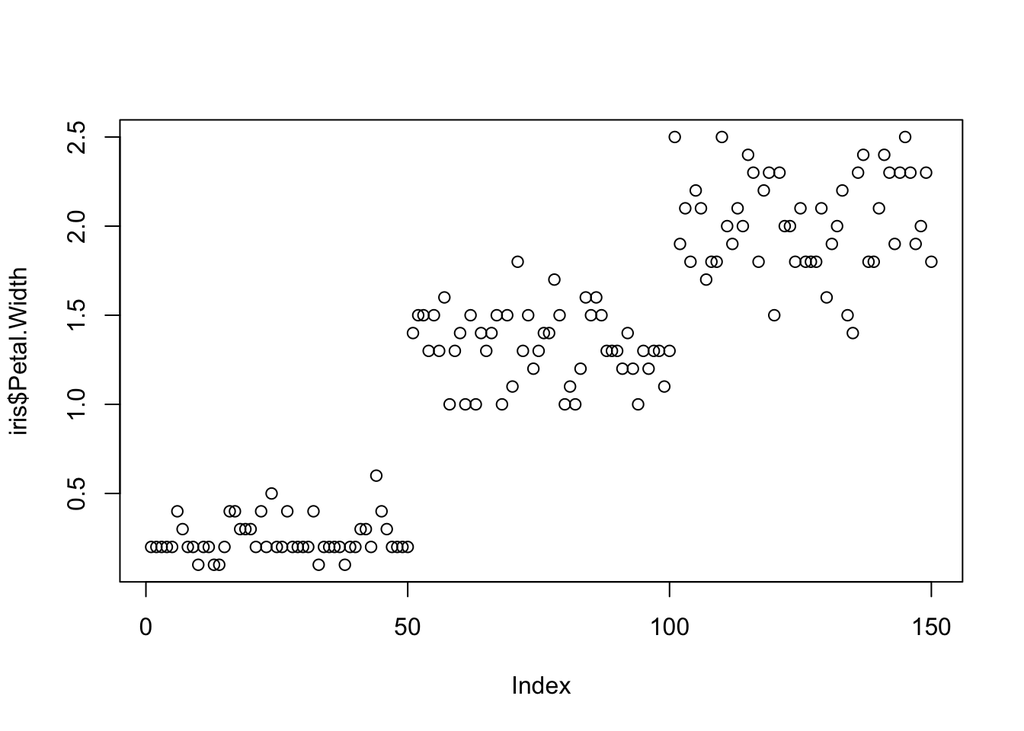

```r
plot(iris$Petal.Width)
```

To plot a scatterplot of one numeric variable against another numeric variable we just need to include both variables as arguments when using the plot() function. For example to plot Petal.Width on the y axis and Petal.Length on the x axis:

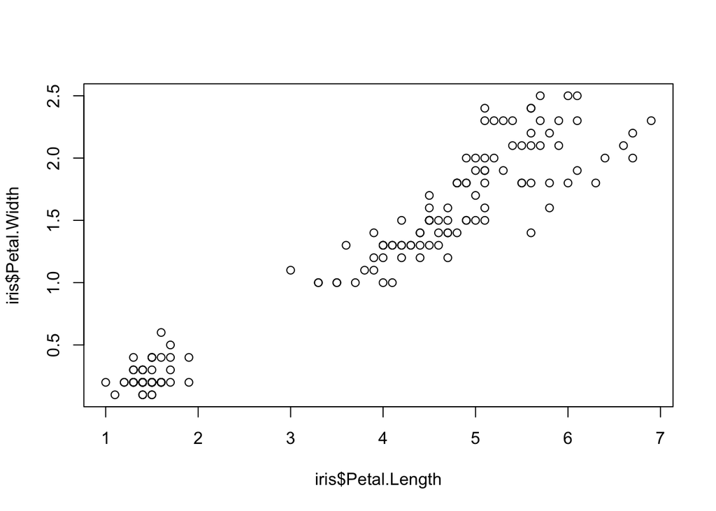

```r
plot(y=iris$Petal.Width, x=iris$Petal.Length)
```

There is an equivalent approach for these types of plots which often causes some confusion at first. You can also use the formula notation when using the plot() function. However, in contrast to the previous method the formula method requires you to specify the y axis variable first, then a ~ and then our x axis variable.

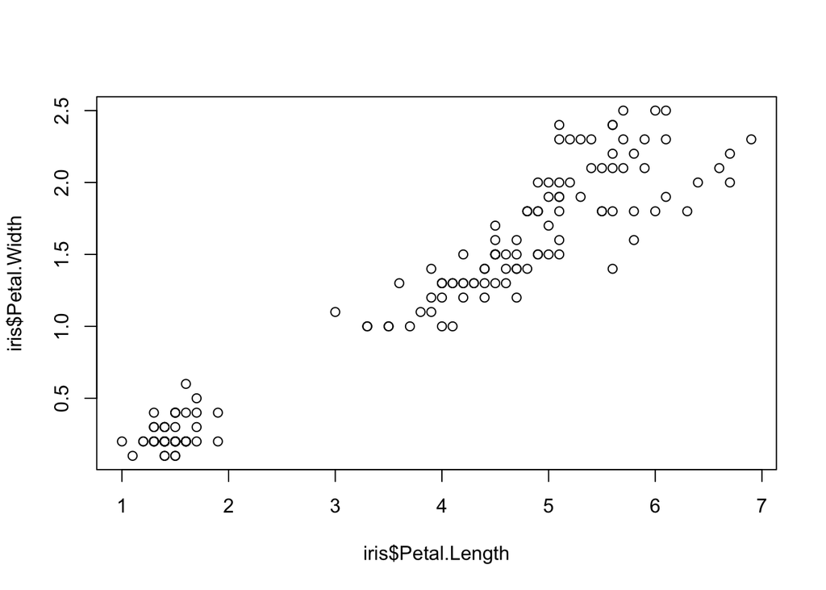

```r
plot(iris$Petal.Width~iris$Petal.Length)
```

Both of these two approaches are equivalent so we suggest that you just choose the one you prefer and go with it.

You can also specify the type of graph you wish to plot using the argument type =. You can plot just the points (type = “p”, this is the default), just lines (type = “l”), both points and lines connected (type = “b”), both points and lines with the lines running through the points (type = “o”) and empty points joined by lines (type = “c”).

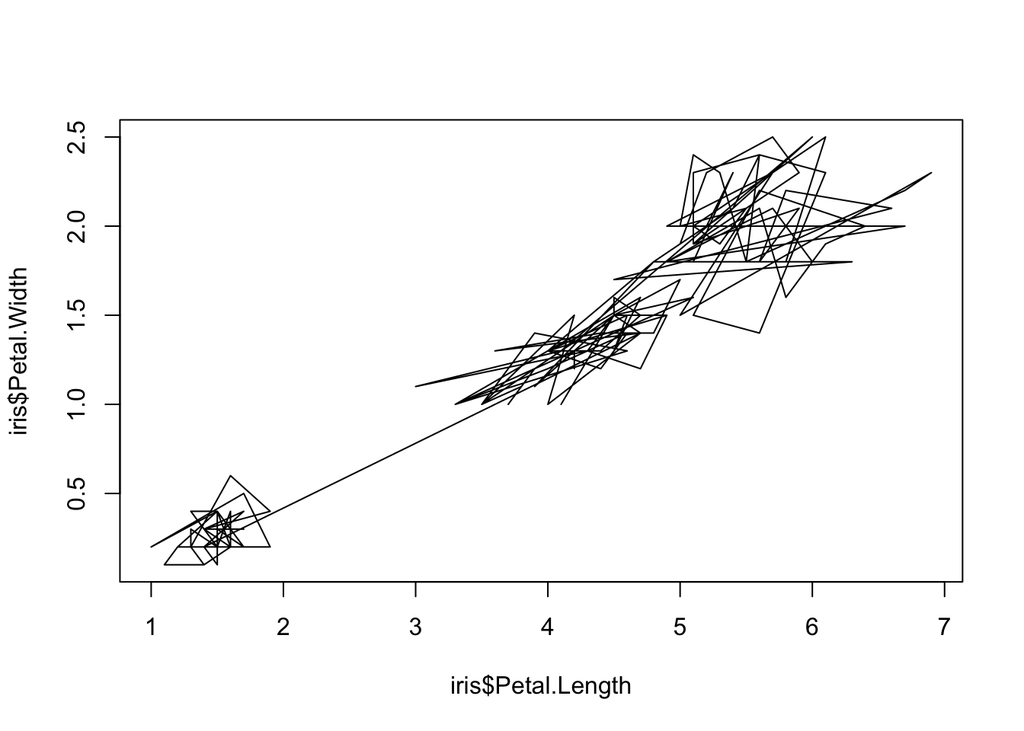

```r
plot(iris$Petal.Width~iris$Petal.Length, type="l")
```

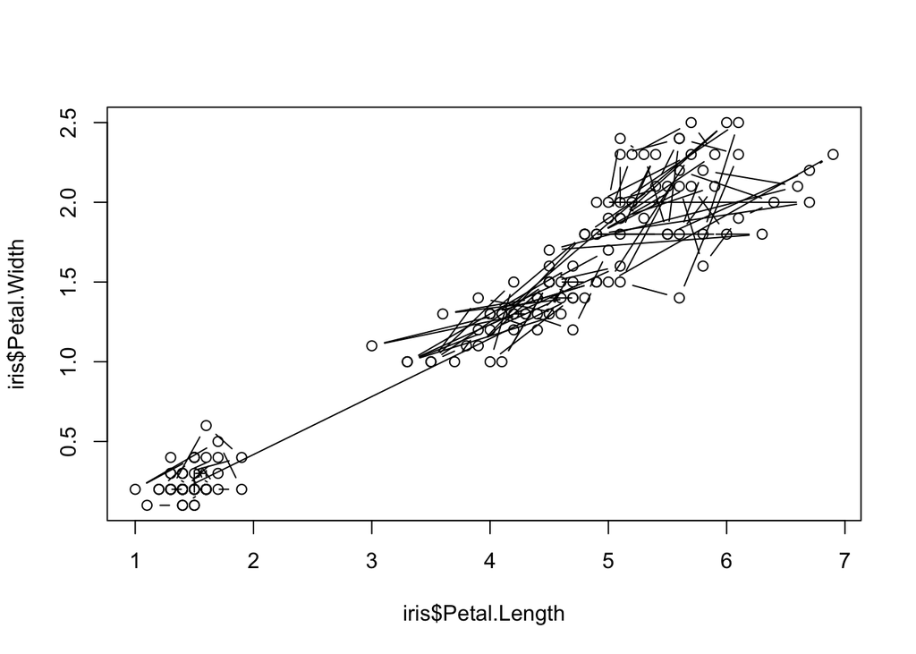

```r
plot(iris$Petal.Width~iris$Petal.Length, type="b")
```

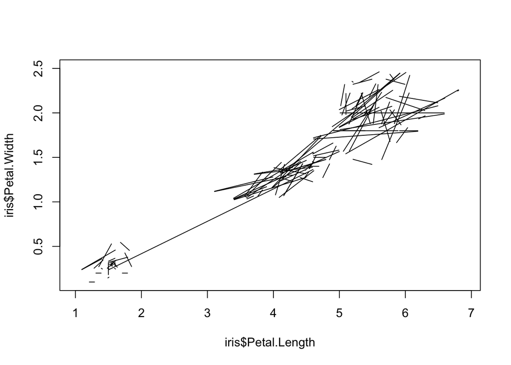

```r
plot(iris$Petal.Width~iris$Petal.Length, type="c")
```

The plots we’ve produced so far don’t look anything particularly special. However, the plot() function is incredibly versatile and can generate a large range of plots which you can customise to your own taste. We’ll cover how to customize plots later. As a quick aside, the plot() function is also what’s known as a generic function which means it can change its default behaviour depending on the type of object used as an argument.

There are lots of types of plots you can make in R. We’ll show two more examples here.

Frequency histograms are useful when you want to get an idea about the distribution of values in a numeric variable. The hist() function takes a numeric vector as its main argument. Let’s generate a histogram of the Petal.Width values.

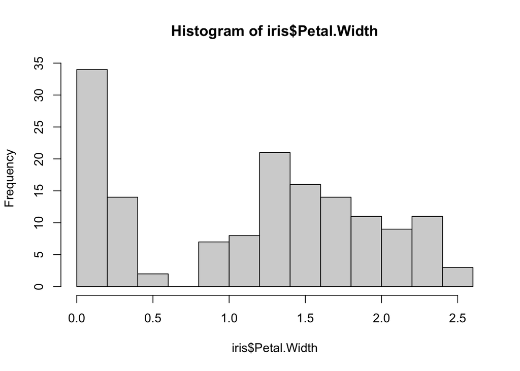

```r
hist(iris$Petal.Width)
```

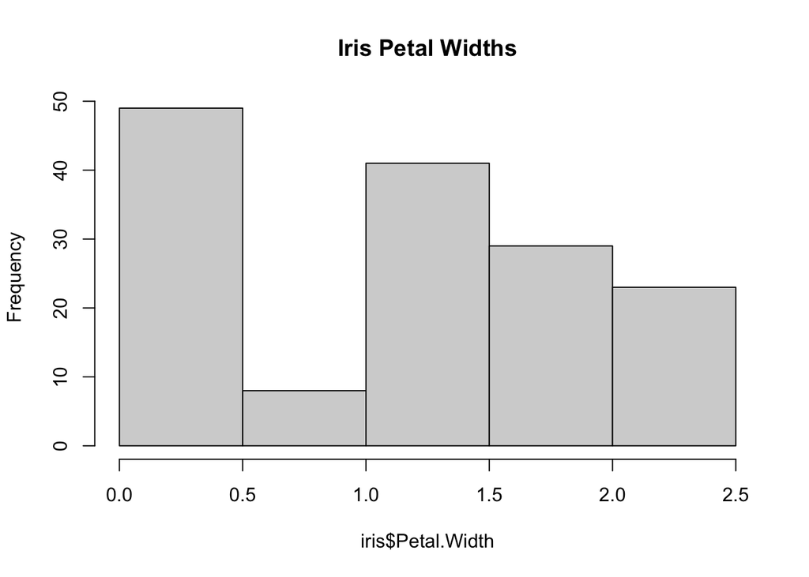

```r
max_val<-max(iris$Petal.Width)

brk <- seq(from = 0, to = max_val, by = 0.5)

hist(iris$Petal.Width, breaks = brk, main = "Iris Petal Widths")
```

Boxplots are another way to explore data, and to see its distribution.

To create a boxplot in R we use the boxplot() function. For example, let’s create a boxplot of the variable Petal.Length from our iris data frame. We can also include a y axis label using the ylab = argument.

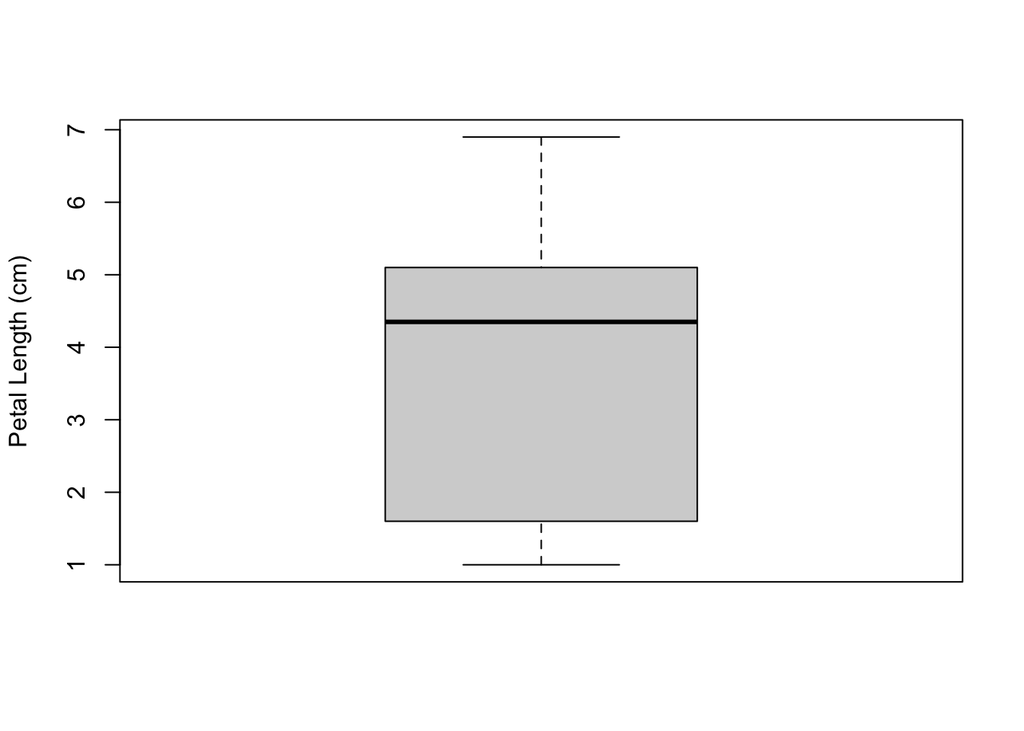

```r
boxplot(iris$Petal.Length, ylab = "Petal Length (cm)")
```

The neat thing about boxplots is that they not only provide a measure of central tendency (the median value) they also give you an idea about the distribution of the data. If the median line is more or less in the middle of the box (between the upper and lower quartiles) and the whiskers are more or less the same length then you can be reasonably sure the distribution of your data is symmetrical.

If we want examine how the distribution of a variable changes between different levels of a factor we need to use the formula notation with the boxplot() function. For example, let’s plot our length variable again, but this time see how this changes with each species. When we use the formula notation with boxplot() we can use the data = argument to save some typing. We’ll also introduce an x axis label using the xlab = argument.

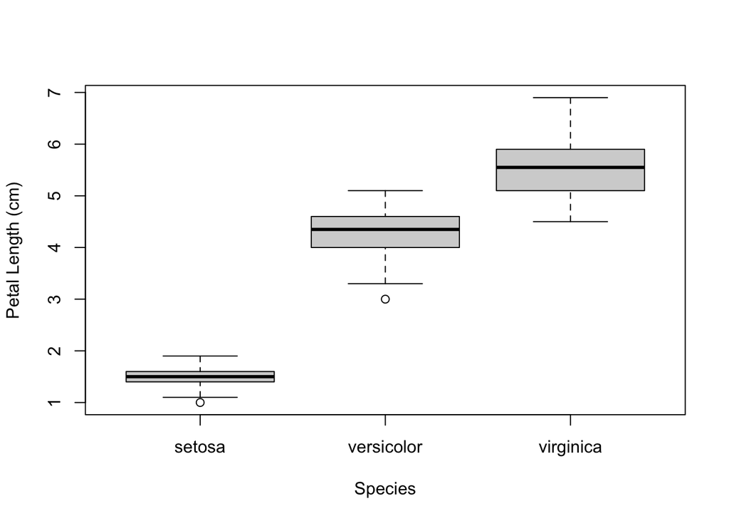

```r
boxplot(Petal.Length ~ Species, data = iris,
         ylab = "Petal Length (cm)", xlab = "Species")
```

As always, more information on plotting is available in the [full tutorial](https://intro2r.com/graphics_base_r.html).

However, while these plotting with R’s built-in functions (also known as “base R”) allows you to do a lot, it has its limits. To make even better plots, we want to explore some add-on features. This brings us to the concept of packages.

## R Packages

The base installation of R comes with many useful packages as standard. These packages will contain many of the functions you will use on a daily basis. However, as you start using R for more diverse projects (and as your own use of R evolves) you will find that there comes a time when you will need to extend R’s capabilities. Happily, many thousands of R users have developed useful code and shared this code as installable packages. You can think of a package as a collection of functions, data and help files collated into a well defined standard structure which you can download and install in R. These packages can be downloaded from a variety of sources but the most popular are CRAN, Bioconductor and GitHub. Currently, CRAN hosts over 15000 packages and is the official repository for user contributed R packages. Bioconductor provides open source software oriented towards bioinformatics and hosts over 1800 R packages. GitHub is a website that hosts git repositories for all sorts of software and projects (not just R). Often, cutting edge development versions of R packages are hosted on GitHub so if you need all the new bells and whistles then this may be an option. However, a potential downside of using the development version of an R package is that it might not be as stable as the version hosted on CRAN (it’s in development!) and updating packages won’t be automatic.

To install a package from CRAN you can use the install.packages() function. For example if you want to install the ‘ggplot2’ package enter the following code into the Console window of RStudio (note: you will need a working internet connection to do this):

```r
#if you do not have ggplot2 installed already, un-comment the following line and run this code snippet

#install.packages('ggplot2')
```

Once you have installed a package onto your computer it is not immediately available for you to use. To use a package you first need to load the package by using the library() function. For example, to load the ggplot2 package you previously installed:

```r
library(ggplot2)
```

The library() function will also load any additional packages required and may print out additional package information. It is important to realise that every time you start a new R session (or restore a previously saved session) you need to load the packages you will be using. We tend to put all our library() statements required for our analysis near the top of our R scripts to make them easily accessible and easy to add to as our code develops. If you try to use a function without first loading the relevant R package you will receive an error message that R could not find the function.